# Exploration of Cereal Data

Exploration of Cereal Data Nathan Diekema 9/30/2021

## Setup

```r
library(tidyverse)
```

## The Data

```r
cereals <- read_csv("data/cereals.csv")
```

```r
head(cereals, 10)
cereals
```

[output not shown]

The cereal dataset has 77 unique cereals. Each cereal has variables such as manufacturer, protein, fat, fiber, calories, and more.

## Data Cleaning and Transformation

```r
cereals <-
  cereals %>%
  drop_na()

cereals %>%
  summary()
```

```
##      name               mfr                type              calories
##  Length:77          Length:77          Length:77          Min.   : 50.0
##  Class :character   Class :character   Class :character   1st Qu.:100.0
##  Mode  :character   Mode  :character   Mode  :character   Median :110.0
##                                                           Mean   :106.9
##                                                           3rd Qu.:110.0
##                                                           Max.   :160.0
##     protein           fat            sodium          fiber
##  Min.   :1.000   Min.   :0.000   Min.   :  0.0   Min.   : 0.000
##  1st Qu.:2.000   1st Qu.:0.000   1st Qu.:130.0   1st Qu.: 1.000
##  Median :3.000   Median :1.000   Median :180.0   Median : 2.000
##  Mean   :2.545   Mean   :1.013   Mean   :159.7   Mean   : 2.152
##  3rd Qu.:3.000   3rd Qu.:2.000   3rd Qu.:210.0   3rd Qu.: 3.000
##  Max.   :6.000   Max.   :5.000   Max.   :320.0   Max.   :14.000
##      carbo          sugars           potass          vitamins
##  Min.   :-1.0   Min.   :-1.000   Min.   : -1.00   Min.   :  0.00
##  1st Qu.:12.0   1st Qu.: 3.000   1st Qu.: 40.00   1st Qu.: 25.00
##  Median :14.0   Median : 7.000   Median : 90.00   Median : 25.00
##  Mean   :14.6   Mean   : 6.922   Mean   : 96.08   Mean   : 28.25
##  3rd Qu.:17.0   3rd Qu.:11.000   3rd Qu.:120.00   3rd Qu.: 25.00
##  Max.   :23.0   Max.   :15.000   Max.   :330.00   Max.   :100.00
##      shelf           weight          cups           rating
##  Min.   :1.000   Min.   :0.50   Min.   :0.250   Min.   :18.04
##  1st Qu.:1.000   1st Qu.:1.00   1st Qu.:0.670   1st Qu.:33.17
##  Median :2.000   Median :1.00   Median :0.750   Median :40.40
##  Mean   :2.208   Mean   :1.03   Mean   :0.821   Mean   :42.67
##  3rd Qu.:3.000   3rd Qu.:1.00   3rd Qu.:1.000   3rd Qu.:50.83
##  Max.   :3.000   Max.   :1.50   Max.   :1.500   Max.   :93.70
```

```r
cereals %>%
  summarize(across(c(sugars),
                   list(mean, median, sd)))
```

```
## # A tibble: 1 x 3
##   sugars_1 sugars_2 sugars_3
##      <dbl>    <dbl>    <dbl>
## 1     6.92        7     4.44
```

```r
#### Write code to show the total calories of all cereals
cereals %>%
  summarize(across(c(calories),
                   list(sum)))
```

```
## # A tibble: 1 x 1
##   calories_1
##        <dbl>
## 1       8230
```

```r
#### Write code to create the variable "cal_per_cup" here

cereals <-
  cereals %>%
  mutate(
    cal_per_cup = calories/cups
  )
summary(cereals)
```

```
##      name               mfr                type              calories
##  Length:77          Length:77          Length:77          Min.   : 50.0
##  Class :character   Class :character   Class :character   1st Qu.:100.0
##  Mode  :character   Mode  :character   Mode  :character   Median :110.0
##                                                           Mean   :106.9
##                                                           3rd Qu.:110.0
##                                                           Max.   :160.0
##     protein           fat            sodium          fiber
##  Min.   :1.000   Min.   :0.000   Min.   :  0.0   Min.   : 0.000
##  1st Qu.:2.000   1st Qu.:0.000   1st Qu.:130.0   1st Qu.: 1.000
##  Median :3.000   Median :1.000   Median :180.0   Median : 2.000
##  Mean   :2.545   Mean   :1.013   Mean   :159.7   Mean   : 2.152
##  3rd Qu.:3.000   3rd Qu.:2.000   3rd Qu.:210.0   3rd Qu.: 3.000
##  Max.   :6.000   Max.   :5.000   Max.   :320.0   Max.   :14.000
##      carbo          sugars           potass          vitamins
##  Min.   :-1.0   Min.   :-1.000   Min.   : -1.00   Min.   :  0.00
##  1st Qu.:12.0   1st Qu.: 3.000   1st Qu.: 40.00   1st Qu.: 25.00
##  Median :14.0   Median : 7.000   Median : 90.00   Median : 25.00
##  Mean   :14.6   Mean   : 6.922   Mean   : 96.08   Mean   : 28.25
##  3rd Qu.:17.0   3rd Qu.:11.000   3rd Qu.:120.00   3rd Qu.: 25.00
##  Max.   :23.0   Max.   :15.000   Max.   :330.00   Max.   :100.00
##      shelf           weight          cups           rating       cal_per_cup
##  Min.   :1.000   Min.   :0.50   Min.   :0.250   Min.   :18.04   Min.   : 50.0
##  1st Qu.:1.000   1st Qu.:1.00   1st Qu.:0.670   1st Qu.:33.17   1st Qu.:110.0
##  Median :2.000   Median :1.00   Median :0.750   Median :40.40   Median :134.3
##  Mean   :2.208   Mean   :1.03   Mean   :0.821   Mean   :42.67   Mean   :143.5
##  3rd Qu.:3.000   3rd Qu.:1.00   3rd Qu.:1.000   3rd Qu.:50.83   3rd Qu.:160.0
##  Max.   :3.000   Max.   :1.50   Max.   :1.500   Max.   :93.70   Max.   :440.0
```

```r
#### Write code to include only Kellogg brand cereals, and only relevant columns

cereals %>%
  select(name, mfr, cal_per_cup) %>%
  filter(mfr == "K")
```

```
## # A tibble: 23 x 3
##    name                      mfr   cal_per_cup
##    <chr>                     <chr>       <dbl>
##  1 All-Bran                  K            212.
##  2 All-Bran with Extra Fiber K            100
##  3 Apple Jacks               K            110
##  4 Corn Flakes               K            100
##  5 Corn Pops                 K            110
##  6 Cracklin' Oat Bran        K            220
##  7 Crispix                   K            110
##  8 Froot Loops               K            110
##  9 Frosted Flakes            K            147.
## 10 Frosted Mini-Wheats       K            125
## # ... with 13 more rows
```

```r
#### Write code to sort the dataset by calories per cup
cereals %>%
  arrange(cal_per_cup)
```

```
## # A tibble: 77 x 17
##    name      mfr   type  calories protein   fat sodium fiber carbo sugars potass
##    <chr>     <chr> <chr>    <dbl>   <dbl> <dbl>  <dbl> <dbl> <dbl>  <dbl>  <dbl>
##  1 Puffed R~ Q     C           50       1     0      0     0    13      0     15
##  2 Puffed W~ Q     C           50       2     0      0     1    10      0     50
##  3 Kix       G     C          110       2     1    260     0    21      3     40
##  4 Shredded~ N     C           80       2     0      0     3    16      0     95
##  5 Honey-co~ P     C          110       1     0    180     0    14     11     35
##  6 Cheerios  G     C          110       6     2    290     2    17      1    105
##  7 Nutri-gr~ K     C           90       3     0    170     3    18      2     90
##  8 Strawber~ N     C           90       2     0     15     3    15      5     90
##  9 Rice Chex R     C          110       1     0    240     0    23      2     30
## 10 All-Bran~ K     C           50       4     0    140    14     8      0    330
## # ... with 67 more rows, and 6 more variables: vitamins <dbl>, shelf <dbl>,
## #   weight <dbl>, cups <dbl>, rating <dbl>, cal_per_cup <dbl>
```

```r
cereals_longer <- cereals %>%
  select(name, mfr, vitamins, protein, fiber, sugars) %>%
  pivot_longer(c(sugars, protein, fiber),
               names_to = "Variable",
               values_to = "Amount")
cereals_longer
```

```
## # A tibble: 231 x 5
##    name                      mfr   vitamins Variable Amount
##    <chr>                     <chr>    <dbl> <chr>     <dbl>
##  1 100% Bran                 N           25 sugars        6
##  2 100% Bran                 N           25 protein       4
##  3 100% Bran                 N           25 fiber        10
##  4 100% Natural Bran         Q            0 sugars        8
##  5 100% Natural Bran         Q            0 protein       3
##  6 100% Natural Bran         Q            0 fiber         2
##  7 All-Bran                  K           25 sugars        5
##  8 All-Bran                  K           25 protein       4
##  9 All-Bran                  K           25 fiber         9
## 10 All-Bran with Extra Fiber K           25 sugars        0
## # ... with 221 more rows
```

## Visualizing the data

```
## No summary function supplied, defaulting to `mean_se()`
```

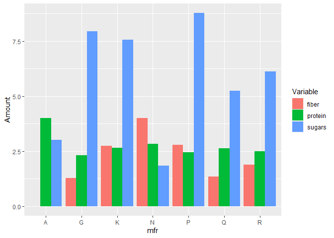

```r
#### Make a plot
ggplot(data = cereals_longer, mapping = aes(x = mfr, y = Amount, fill = Variable)) +
  geom_bar(position="dodge", stat="summary")
```

## Conclusion

What did you learn about cereals? Write a few sentences summarizing your findings, knit your document, and admire your handiwork!

When comparing average protein, fiber, and sugar content between cereal manufacturers, we can make some inferences about how healthy some brands are compared to others. From the chart above it can be observed that Nature’s Path is by far the “healthiest” company with the lowest average sugar content, highest average fiber, and decent protein. Kellogs, Post, and General Mills on the other hand have a very high average sugar content and less fiber and protein. This makes sense because these cereal brands are generally known for making popular “sugary” cereals that appeal to younger kids but are not necessarily healthy.